# Time Series Analysis and Modeling

https://www.datascience.com/blog/introduction-to-forecasting-with-arima-in-r-learn-data-science-tutorials

```r
library('ggplot2')
library('forecast')
library('tseries')
```

### Step1: Import data

We start out by reading in the analysis dataset. Here we are using a dataset on the number of bicycles checkouts from a bike sharing service, which is available as part of the UCI Machine Learning Repository. We will be using the dataset aggregated at daily level.

```r
daily_data = read.csv('./Bike-Sharing-Dataset/day.csv', header=TRUE, stringsAsFactors=FALSE)
```

### Step 2: Examine Your Data

A good stating point is to plot the series and visually examine it for any outliers, volatility, or irregularities. In this case, bicycle checkouts are showing a lot of fluctuations from one day to another. However, even with this volatility present, we already see some patterns emerge. For example, lower usage of bicycles occurs in the winter months and higher checkout numbers are observed in the summer months:

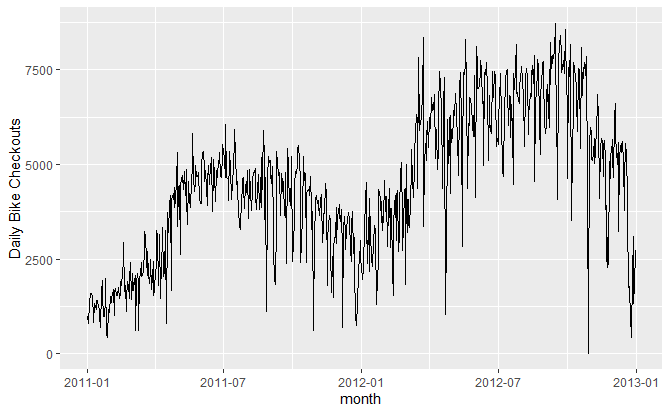

```r
daily_data$Date = as.Date(daily_data$dteday)

ggplot(daily_data, aes(Date, cnt)) + geom_line() + scale_x_date('month')  + ylab("Daily Bike Checkouts") +
            xlab("")
```

In some cases, the number of bicycles checked out dropped below 100 on day and rose to over 4,000 the next day. These are suspected outliers that could bias the model by skewing statistical summaries. R provides a convenient method for removing time series outliers: tsclean() as part of its forecast package. tsclean() identifies and replaces outliers using series smoothing and decomposition.

This method is also capable of inputing missing values in the series if there are any.Note that we are using the ts() command to create a time series object to pass to tsclean():

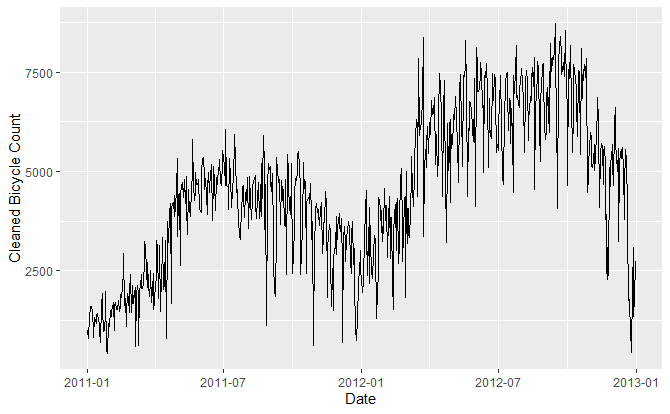

```r
count_ts = ts(daily_data[, c('cnt')])

daily_data$clean_cnt = tsclean(count_ts)

ggplot() +
  geom_line(data = daily_data, aes(x = Date, y = clean_cnt)) + ylab('Cleaned Bicycle Count')
```

Even after removing outliers, the daily data is still pretty volatile. Visually, we could a draw a line through the series tracing its bigger troughs and peaks while smoothing out noisy fluctuations. This line can be described by one of the simplest — but also very useful —concepts in time series analysis known as a moving average. It is an intuitive concept that averages points across several time periods, thereby smoothing the observed data into a more stable predictable series.

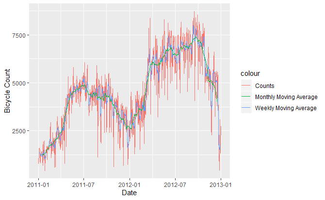

```r
daily_data$cnt_ma = ma(daily_data$clean_cnt, order=7) # using the clean count with no outliers
daily_data$cnt_ma30 = ma(daily_data$clean_cnt, order=30)


ggplot() +
  geom_line(data = daily_data, aes(x = Date, y = clean_cnt, colour = "Counts")) +
  geom_line(data = daily_data, aes(x = Date, y = cnt_ma,   colour = "Weekly Moving Average"))  +
  geom_line(data = daily_data, aes(x = Date, y = cnt_ma30, colour = "Monthly Moving Average"))  +
  ylab('Bicycle Count')
```

In addition to volatility, modeling daily level data might require specifying multiple seasonality levels, such day of the week, week of the year, month of the year, holidays, etc. For the sake of simplicity, we will model the smoothed series of weekly moving average (as shown by the blue line above).

### Step 3: Decompose Your Data

The building blocks of a time series analysis are seasonality, trend, and cycle. These intuitive components capture the historical patterns in the series. Not every series will have all three (or any) of these components, but if they are present, deconstructing the series can help you understand its behavior and prepare a foundation for building a forecasting model.

Seasonal component refers to fluctuations in the data related to calendar cycles. For example, more people might be riding bikes in the summer and during warm weather, and less during colder months. Usually, seasonality is fixed at some number; for instance, quarter or month of the year.

Trend component is the overall pattern of the series: Is the number of bikes rented increasing or decreasing over time?

Cycle component consists of decreasing or increasing patterns that are not seasonal. Usually, trend and cycle components are grouped together. Trend-cycle component is estimated using moving averages.

Finally, part of the series that can’t be attributed to seasonal, cycle, or trend components is referred to as residual or error.

Formally, if Y is the number of bikes rented, we can decompose the series in two ways: by using either an additive or multiplicative model,

$$Y = S_t + T_t + E_t$$
$$Y = S_t * T_t * E_t$$

where St is the seasonal component, T is trend and cycle, and E is the remaining error.

An additive model is usually more appropriate when the seasonal or trend component is not proportional to the level of the series, as we can just overlay (i.e. add) components together to reconstruct the series. On the other hand, if the seasonality component changes with the level or trend of the series, a simple “overlay,” or addition of components, won’t be sufficient to reconstruct the series. In that case, a multiplicative model might be more appropriate.

First, we calculate seasonal component of the data using stl(). STL is a flexible function for decomposing and forecasting the series. It calculates the seasonal component of the series using smoothing, and adjusts the original series by subtracting seasonality in two simple lines:

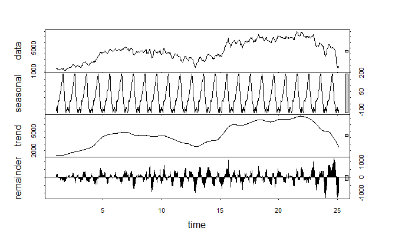

```r
count_ma = ts(na.omit(daily_data$cnt_ma), frequency=30)
decomp = stl(count_ma, s.window="periodic")
deseasonal_cnt <- seasadj(decomp)
plot(decomp)
```

Note that stl() by default assumes additive model structure. Use allow.multiplicative.trend=TRUE to incorporate the multiplicative model.

In the case of additive model structure, the same task of decomposing the series and removing the seasonality can be accomplished by simply subtracting the seasonal component from the original series. seasadj() is a convenient method inside the forecast package.

As for the frequency parameter in ts() object, we are specifying periodicity of the data, i.e., number of observations per period. Since we are using smoothed daily data, we have 30 observations per month.

### Step 4: Stationarity

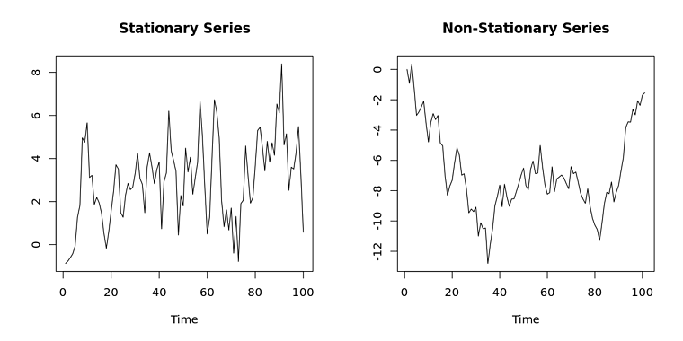

The augmented Dickey-Fuller (ADF) test is a formal statistical test for stationarity. The null hypothesis assumes that the series is non-stationary. ADF procedure tests whether the change in Y can be explained by lagged value and a linear trend. If contribution of the lagged value to the change in Y is non-significant and there is a presence of a trend component, the series is non-stationary and null hypothesis will not be rejected. Our bicycle data is non-stationary; the average number of bike checkouts changes through time, levels change, etc. A formal ADF test does not reject the null hypothesis of non-stationarity, confirming our visual inspection:

```r
adf.test(count_ma, alternative = "stationary")
```

```
p-value greater than printed p-value
```

```
    Augmented Dickey-Fuller Test

data:  count_ma
Dickey-Fuller = -0.2557, Lag order = 8, p-value = 0.99
alternative hypothesis: stationary
```

Usually, non-stationary series can be corrected by a simple transformation such as differencing. Differencing the series can help in removing its trend or cycles. The idea behind differencing is that, if the original data series does not have constant properties over time, then the change from one period to another might. The difference is calculated by subtracting one period’s values from the previous period’s values:
$$Y_{d_t} = Y_t - Y_{t-1}$$
Higher order differences are calculated in a similar fashion. For example, second order differencing (d = 2) is simply expanded to include second lag of the series:

$$Y_{d2_t} = Y_{d_t} - Y_{d_t-1} = (Y_t - Y_{t-1}) - (Y_{t-1} - Y_{t-2})$$
Similarly, differencing can be used if there is a seasonal pattern at specific lags. In such a case, subtracting a value for the “season” from a previous period represents the change from one period to another, as well as from one season to another:

$$Y_{d_t} = (Y_t - Y_{t-s}) - (Y_{t-1} - Y_{t-s-1} )$$

The number of differences performed is represented by the d component of ARIMA. Now, we move on to diagnostics that can help determine the order of differencing.

### Step 5: Autocorrelations and Choosing Model Order

Autocorrelation plots (also known as ACF or the auto correlation function) are a useful visual tool in determining whether a series is stationary. These plots can also help to choose the order parameters for ARIMA model. If the series is correlated with its lags then, generally, there are some trend or seasonal components and therefore its statistical properties are not constant over time.

ACF plots display correlation between a series and its lags. In addition to suggesting the order of differencing, ACF plots can help in determining the order of the M A (q) model. Partial autocorrelation plots (PACF), as the name suggests, display correlation between a variable and its lags that is not explained by previous lags. PACF plots are useful when determining the order of the AR(p) model.

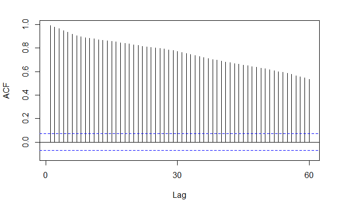

```r
Acf(count_ma, main='')
```

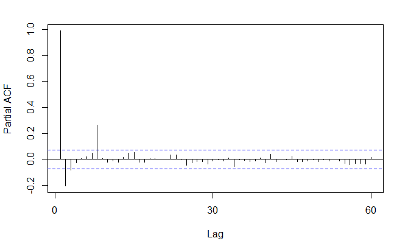

```r
Pacf(count_ma, main='')
```

We can start with the order of d = 1 and re-evaluate whether further differencing is needed.

The augmented Dickey-Fuller test on differenced data rejects the null hypotheses of non-stationarity. Plotting the differenced series, we see an oscillating pattern around 0 with no visible strong trend. This suggests that differencing of order 1 terms is sufficient and should be included in the model.

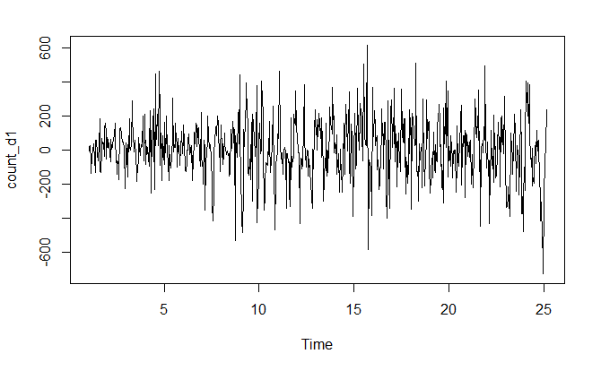

```r
count_d1 = diff(deseasonal_cnt, differences = 1)
plot(count_d1)
```

```r
adf.test(count_d1, alternative = "stationary")
```

```
p-value smaller than printed p-value
```

```
    Augmented Dickey-Fuller Test

data:  count_d1
Dickey-Fuller = -9.9255, Lag order = 8, p-value = 0.01
alternative hypothesis: stationary
```

Next, spikes at particular lags of the differenced series can help inform the choice of p or q for our model:

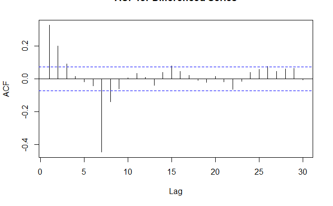

```r
Acf(count_d1, main='ACF for Differenced Series', lag.max = 30)
```

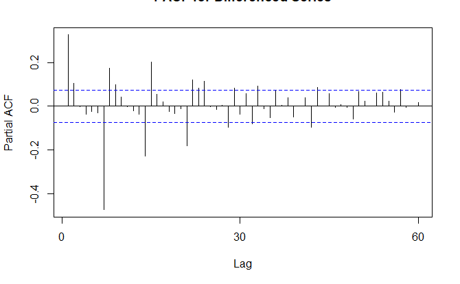

```r
Pacf(count_d1, main='PACF for Differenced Series')
```

There are significant auto correlations at lag 1 and 2 and beyond. Partial correlation plots show a significant spike at lag 1 and 7. This suggests that we might want to test models with AR or MA components of order 1, 2, or 7. A spike at lag 7 might suggest that there is a seasonal pattern present, perhaps as day of the week. We talk about how to choose model order in the next step.

### Step 6: Fitting an ARIMA model

Now let’s fit a model. The forecast package allows the user to explicitly specify the order of the model using the arima() function, or **automatically generate a set of optimal (p, d, q) using auto.arima()**. This function searches through combinations of order parameters and picks the set that optimizes model fit criteria.

There exist a number of such criteria for comparing quality of fit across multiple models. Two of the most widely used are Akaike information criteria (AIC) and Baysian information criteria (BIC). These criteria are closely related and can be interpreted as an estimate of how much information would be lost if a given model is chosen. When comparing models, one wants to minimize AIC and BIC.

While auto.arima() can be very useful, it is still important to complete steps 1-5 in order to understand the series and interpret model results. Note that auto.arima() also allows the user to specify maximum order for (p, d, q), which is set to 5 by default.

We can specify non-seasonal ARIMA structure and fit the model to **de-seasonalize** data. Parameters (2,1,0) suggested by the automated procedure are in line with our expectations based on the steps above; the model incorporates differencing of degree 1, and uses an autoregressive term of second lag and no MA term:

```r
auto.arima(deseasonal_cnt, seasonal=FALSE)
```

```
Series: deseasonal_cnt
ARIMA(2,1,0)

Coefficients:
         ar1     ar2
      0.2929  0.1055
s.e.  0.0370  0.0370

sigma^2 estimated as 26137:  log likelihood=-4708.32
AIC=9422.64   AICc=9422.68   BIC=9436.4
```

$$\hat Y_{d_t} = 0.2929 Y_{t-1} + 0.1055 Y_{t-2} + E$$

where E is some error and the original series is differenced with order 1.

### Step 7: Evaluate and Iterate

So now we have fitted a model that can produce a forecast, but does it make sense? Can we trust this model? We can start by examining ACF and PACF plots for model residuals. If model order parameters and structure are correctly specified, we would expect no significant autocorrelations present.

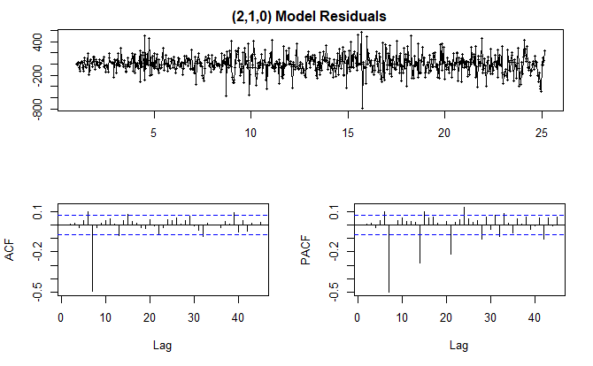

```r
fit<-auto.arima(deseasonal_cnt, seasonal=FALSE)
tsdisplay(residuals(fit), lag.max=45, main='(2,1,0) Model Residuals')
```

There is a clear pattern present in ACF/PACF and model residuals plots repeating at lag 7. This suggests that our model may be better off with a different specification, such as p = 7 or q = 7.

```r
fit2 = arima(deseasonal_cnt, order=c(2,1,7))

fit2
```

```
Call:
arima(x = deseasonal_cnt, order = c(2, 1, 7))

Coefficients:
        ar1     ar2     ma1     ma2     ma3     ma4     ma5     ma6      ma7
      0.282  0.0351  0.1380  0.1410  0.1151  0.1117  0.1196  0.1388  -0.8442
s.e.  0.047  0.0435  0.0295  0.0286  0.0286  0.0286  0.0270  0.0273   0.0298

sigma^2 estimated as 14377:  log likelihood = -4502.95,  aic = 9025.91
```

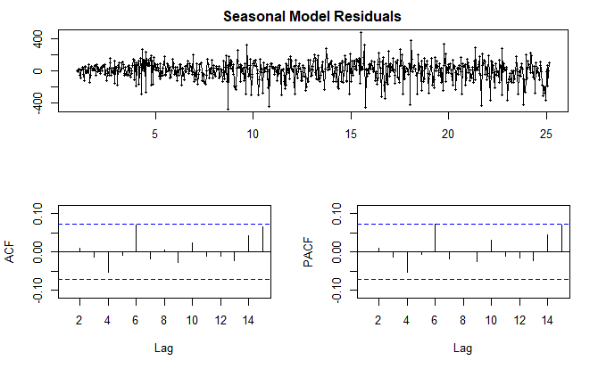

```r
tsdisplay(residuals(fit2), lag.max=15, main='Seasonal Model Residuals')
```

Forecasting using a fitted model is straightforward in R. We can specify forecast horizon h periods ahead for predictions to be made, and use the fitted model to generate those predictions:

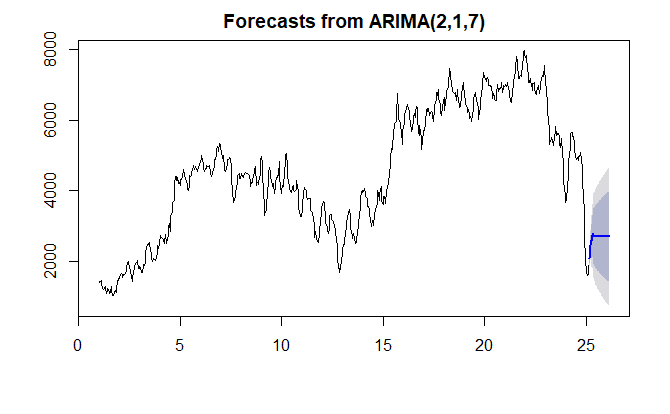

```r
fcast <- forecast(fit2, h=30)
plot(fcast)
```

The light blue line above shows the fit provided by the model, but what if we wanted to get a sense of how the model will perform in the future? One method is to reserve a portion of our data as a “hold-out” set, fit the model, and then compare the forecast to the actual observed values:

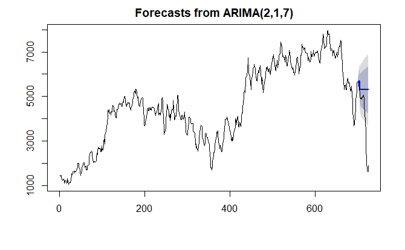

```r
hold <- window(ts(deseasonal_cnt), start=700)

fit_no_holdout = arima(ts(deseasonal_cnt[-c(700:725)]), order=c(2,1,7))

fcast_no_holdout <- forecast(fit_no_holdout,h=25)
plot(fcast_no_holdout)
lines(ts(deseasonal_cnt))
```

However, the blue line representing forecast seems very naive: It goes close to a straight line fairly soon, which seems unlikely given past behavior of the series. Recall that the model is assuming a series with no seasonality, and is differencing the original non-stationary data. In other words, plotted predictions are based on the assumption that there will be no other seasonal fluctuations in the data and the change in number of bicycles from one day to another is more or less constant in mean and variance. This forecast may be a naive model, but it illustrates the process of choosing an ARIMA model and could also serve as a benchmark to grade against as more complex models are built.

How can we improve the forecast and iterate on this model? One simple change is to add back the seasonal component we extracted earlier. Another approach would be to allow for (P, D, Q) components to be included to the model, which is a default in the auto.arima() function. Re-fitting the model on the same data, we see that there still might be some seasonal pattern in the series, with the seasonal component described by AR(1):

```r
fit_w_seasonality = auto.arima(deseasonal_cnt, seasonal=TRUE)
fit_w_seasonality
```

```
Series: deseasonal_cnt
ARIMA(2,1,2)(1,0,0)[30]

Coefficients:
         ar1      ar2      ma1     ma2    sar1
      1.3644  -0.8027  -1.2903  0.9146  0.0100
s.e.  0.0372   0.0347   0.0255  0.0202  0.0388

sigma^2 estimated as 24810:  log likelihood=-4688.59
AIC=9389.17   AICc=9389.29   BIC=9416.68
```

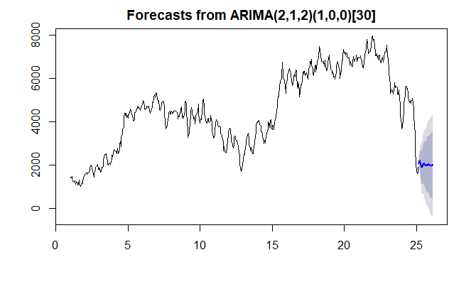

```r
seas_fcast <- forecast(fit_w_seasonality, h=30)
plot(seas_fcast)
```

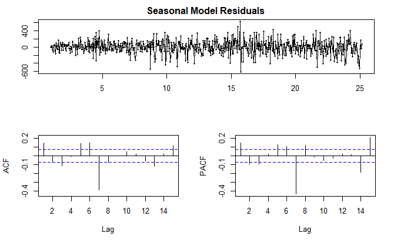

```r
tsdisplay(residuals(fit_w_seasonality), lag.max=15, main='Seasonal Model Residuals')
```

**Note that (p,d,q) parameters also changed after we included a seasonal component**. We can go through the same process of evaluating model residuals and ACF/PACF plots and adjusting the structure if necessary. For example, we notice the same evidence of higher order is present in the auto correlations with lag 7, which suggests that a higher-order component might be needed:

- Tried increasing the power of P and Q in seasonal term, but didn’t help much.
- Turned out increasing the power of p and q of the non-seasonal part helped a lot.

```r
fit_w_seasonality_2 <- arima(deseasonal_cnt, order=c(2,1,7), seasonal = list(order = c(1, 0, 0), period = 30))
fit_w_seasonality_2
```

```
Call:
arima(x = deseasonal_cnt, order = c(2, 1, 7), seasonal = list(order = c(1, 0,
    0), period = 30))

Coefficients:
         ar1     ar2     ma1     ma2     ma3     ma4     ma5     ma6      ma7
      0.2811  0.0337  0.1391  0.1431  0.1166  0.1131  0.1202  0.1395  -0.8431
s.e.  0.0471  0.0437  0.0298  0.0293  0.0289  0.0289  0.0271  0.0274   0.0299
         sar1
      -0.0140
s.e.   0.0398

sigma^2 estimated as 14375:  log likelihood = -4502.89,  aic = 9027.79
```

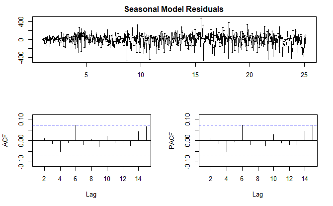

```r
tsdisplay(residuals(fit_w_seasonality_2), lag.max=15, main='Seasonal Model Residuals')
```

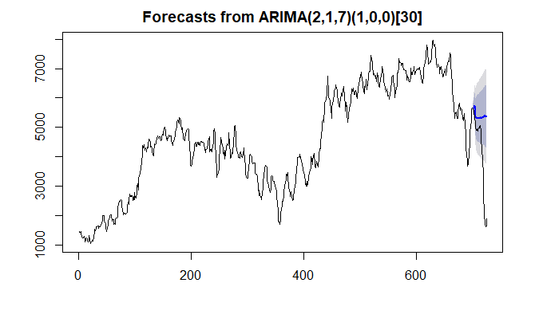

```r
hold <- window(ts(deseasonal_cnt), start=700)

fit_w_seasonality_2_no_holdout = arima(ts(deseasonal_cnt[-c(700:725)]), order=c(2,1,7), seasonal = list(order = c(1, 0, 0), period = 30))

fcast_no_holdout <- forecast(fit_w_seasonality_2_no_holdout,h=25)
plot(fcast_no_holdout)
lines(ts(deseasonal_cnt))
```

Both forecast estimates above are provided with confidence bounds: 80% confidence limits shaded in darker blue, and 95% in lighter blue. Longer term forecasts will usually have more uncertainty, as the model will regress future Y on previously predicted values. This is reflected in the shape of the confidence bounds in this case, as they start to widen with increasing horizon. The pattern in confidence bounds may signal the need for a more stable model. It is very important to look at prediction bounds and keep in mind the expected error associated with point estimates.

After an initial naive model is built, it’s natural to wonder how to improve on it. Other forecasting techniques, such as exponential smoothing, would help make the model more accurate using a weighted combinations of seasonality, trend, and historical values to make predictions. In addition, daily bicycle demand is probably highly dependent on other factors, such weather, holidays, time of the day, etc. One could try fitting time series models that allow for inclusion of other predictors using methods such ARMAX or dynamic regression. These more complex models allow for control of other factors in predicting the time series.

To summarize, the procedure outlined in this tutorial is an introduction to ARIMA modeling. Material here can be used as a general guideline to examining your series, using ACF and PACF plots to choose model order, and fitting the model in R.